# Nuisance Correction

## White Matter & Stimulus Correlation Investigation

### 3/6/17 Deliverable

Goal: For task-based fMRI datasets, verify that the 5 components from white matter obtained from our current compcor method for nuisance correction do not correlate with the task-based stimulus.

To do this, I utilized the NKI dataset and used the checkerboard task (TR = 1400 ms) for subjects 0021001, 0021002, 0021006, 0021018, 0021024. The task followed the following layout:  
Checker Block Paradigm:  
block_types = [ FIXATION, CHECKER, FIXATION, CHECKER, FIXATION, CHECKER ]  
block_durations = [ 20.0, 20.0, 20.0, 20.0, 20.0, 20.0 ] # seconds

The five components of the white matter obtained from the nuisance correction were correlated with a hemodynamic response that had been convolved with the stimulus onset timeseries. The components of the white matter were determined from the following code:

```python
from ndmg.utils import utils as mgu
import nibabel as nb
import numpy as np
import scipy.signal as signal
fmri = './data/NKI_task/output/reg_fmri/0021024_checkerboard_1400_1_aligned.nii.gz'
amri = './data/NKI_task/output/reg_struct/0021024_checkerboard_1400_1_anat_aligned.nii.gz'
amask = './FNGS_server/atlases/mask/MNI152_T1-2mm_brain_mask.nii.gz'
an = 1
outdir = './'
lvmask = './FNGS_server/atlases/mask/HarvOx_lv_thr25-2mm.nii.gz'
amask_im = nb.load(amask)
amm = amask_im.get_data()
lv_im = nb.load(lvmask)
lvm = lv_im.get_data()
fmri_name = mgu().get_filename(fmri)
anat_name = mgu().get_filename(amri)
nuisname = "".join([anat_name, "_nuis"])
map_path = mgu().name_tmps(outdir, nuisname, "_map")
wmm_path = mgu().name_tmps(outdir, nuisname, "_wm_mask.nii.gz")
er_wmm_path = mgu().name_tmps(outdir, nuisname, "_eroded_wm_mask.nii.gz")
cmd1 = " ".join(["fast -t", str(int(an)), "-n 3 -o", map_path, amri])
mgu().execute_cmd(cmd1)
wm_prob = map_path + "_pve_2.nii.gz"
prob = nb.load(wm_prob)
prob_dat = prob.get_data()
mask = (prob_dat > .99).astype(int)
img = nb.Nifti1Image(mask,header = prob.header,affine = prob.get_affine())
nb.save(img, wmm_path)
mask_img = nb.load(wmm_path)
mask = mask_img.get_data()
for i in range(0, 2):
    erode_mask = np.zeros(mask.shape)
    x, y, z = np.where(mask != 0)
    if (x.shape == y.shape and y.shape == z.shape):
        for j in range(0, x.shape[0]):
            md = mask.shape
            if (mask[x[j],y[j],z[j]] and
                mask[np.min((x[j]+1, md[0]-1)),y[j],z[j]] and
                mask[x[j],np.min((y[j]+1, md[1]-1)),z[j]] and
                mask[x[j],y[j],np.min((z[j]+1, md[2]-1))] and
                mask[np.max((x[j]-1, 0)),y[j],z[j]] and
                mask[x[j],np.max((y[j]-1, 0)),z[j]] and
                mask[x[j],y[j],np.max((z[j]-1, 0))]):
                erode_mask[x[j],y[j],z[j]] = 1
    else:
        raise ValueError('Your mask erosion has an invalid shape.')
    mask = erode_mask

eroded_mask_img = nb.Nifti1Image(mask,header = mask_img.header,affine = mask_img.get_affine())
nb.save(eroded_mask_img, er_wmm_path)
wmm = mask
fmri_im = nb.load(fmri)
amri_im = nb.load(amri)
fmri_dat = fmri_im.get_data()
voxel = fmri_dat[fmri_dat.sum(axis=3) > 0, :].T
wm_ts = fmri_dat[wmm != 0, :].T
lv_ts = fmri_dat[lvm != 0, :].T
t = voxel.shape[0]
lin_reg = np.array(range(0, t))
quad_reg = np.array(range(0, t))**2
csf_reg = lv_ts.mean(axis=1)
wm_ts = wm_ts[:, wm_ts.std(axis=0) != 0]
wm_ts = signal.detrend(wm_ts, axis=0, type='linear')
wm_ts = wm_ts - wm_ts.mean(axis=0)
wm_ts = np.divide(wm_ts, wm_ts.std(axis=0))
U, s, V = np.linalg.svd(wm_ts)
wm_reg = U[:, 0:5]
np.savetxt('./data/NKI_task/output/wmreg_0021024.txt', wm_reg)
```

The hemodynamic response timeseries was generated by the following code:

```python
import numpy as np
from nipy.modalities.fmri import hrf, utils
hrf_func = utils.lambdify_t(hrf.glover(utils.T))
t = np.linspace(0,134.4,97)
h = hrf_func(t)
s = np.zeros(97)
s[15]=1
s[43]=1
s[72]=1
x = np.convolve(h,s)
x = x[:97]
np.savetxt('./data/NKI_task/output/hs.txt', x)
```

This was then evaluated as follows:

```python
%matplotlib inline
import numpy as np
import matplotlib.pyplot as plt
fnames = ['./wmreg_0021001.txt', './wmreg_0021002.txt', './wmreg_0021006.txt', './wmreg_0021018.txt', './wmreg_0021024.txt']
x = np.zeros((5,97,5))
for i in range(x.shape[0]):
    x[i,:,:] = np.loadtxt(fnames[i])[:97,:]
y = np.loadtxt('./hs.txt')
coef = np.zeros((5,5))
for i in range(x.shape[0]):
    for j in range(x.shape[2]):
        coef[i,j] = np.correlate(x[i,:,j],y)
print coef
```

```
[[-0.08192889  0.11440676  0.14358005 -0.04842459 -0.09450677]
 [ 0.44189905  0.31562775  0.28397913  0.05871613  0.04316753]
 [-0.15978514 -0.10278549 -0.08231876 -0.0795735   0.02157284]
 [ 0.02395116  0.06586467 -0.01213258  0.16136122 -0.13889902]
 [ 0.026847    0.0908491  -0.02700919 -0.05273092  0.00150872]]
```

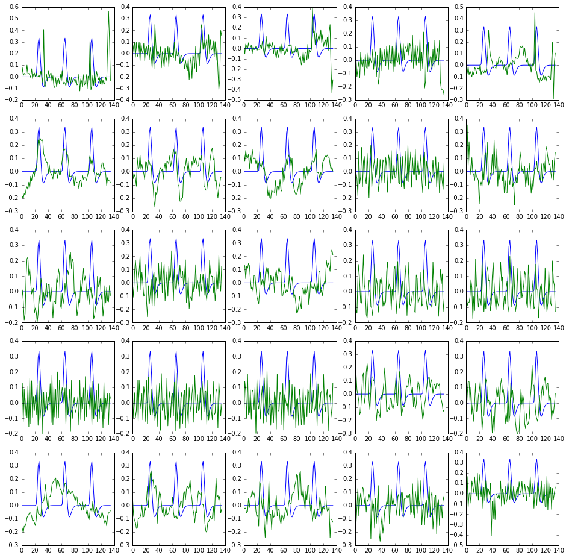

```python
t = np.linspace(0,134.4,97)
plt.figure(figsize=(16,16))
for i in range(x.shape[0]):
    for j in range(x.shape[2]):
        r = x.shape[0]*i+j+1
        plt.subplot(x.shape[0], x.shape[2], r)
        plt.plot(t,y)
        plt.plot(t,x[i,:,j])
```

Other than the first three components for subject 0021002, the white matter components have minimal correlation with the hemodynamic response that occurs at the stimulus onsets. It would thus appear that this method of nuisance correction is sound, as the majority of the correlation coefficients are very close to zero, and the white matter is therefore uncorrelated with the stimulus.